# Spatial Units of Analysis (SUoA) in Crime Location Choice Studies: A Narrative Review of SUoA Selection Decisions

# Abstract

**Background:** Spatial Units of Analysis (SUoA) selection plays a crucial role in shaping our understanding of crime location choice. Choosing an appropriate SUoA is important because different units can lead to substantially different conclusions about offender decision-making, environmental context, and the effectiveness of place-based interventions. In this study, we examine SUoA selection practices to assess whether these decisions reflect the underlying theoretical alignment or stem from practical and methodological considerations.

**Methods:** We conducted a narrative review that involved searching four databases and identifying 2,325 papers. After removing duplicates and irrelevant studies, we screened 1667 papers and assessed 80 reports for eligibility, retaining 49 studies representing 51 observations. We then examined SUoA selection practices, variable complexity, and data limitations through descriptive analysis and mixed-effects regression models.

**Conclusions:** Our review indicates that crime-location-choice research generally employs SUoA thoughtfully, aligning them with theoretical aims while working within practical and data constraints. Rather than reflecting arbitrary choices, the observed variation appears to stem from deliberate, context-sensitive decisions. Strengthening data infrastructures and promoting standardization across jurisdictions may further enhance the comparability and cumulative value of future studies.

# Introduction

Crime concentrates in specific locations, creating spatial patterns that researchers analyze using discrete choice models to understand offender location selection (Bernasco et al., 2013; Vandeviver et al., 2015). These models conceptualize crime location selection as a rational process in which offenders evaluate potential targets based on expected costs and benefits. SUoA refers to the discrete geographical area or boundary-such as a property, street segment, grid cell or other such units used to represent alternatives in crime location choice models.

Recent empirical studies reveal considerable diversity in SUoA choices, spanning from individual properties (Langton & Steenbeek, 2017; Vandeviver et al., 2015) to census blocks (Bernasco et al., 2013), street segments (Bernasco & Jacques, 2015), neighborhoods (Song et al., 2017), administrative districts (Townsley et al., 2015), and grid cells (Hanayama et al., 2018). For example, Vandeviver et al. (2015) analyzed individual residential properties (136 m² average) in Belgium, while Bernasco et al. (2013) examined census blocks (19,680 m² average) in Chicago. The choice of SUoA determines the spatial resolution of analysis, influences which environmental and social factors are measurable, and shapes the interpretation of results (Fotheringham & Wong, 1991; Openshaw, 1984; Weisburd et al., 2012). This methodological choice directly affects statistical power, result interpretation, and policy relevance. Despite its fundamental importance, the factors that drive SUoA selection decisions in crime location choice research have received little systematic attention.

This study addresses this gap by systematically examining how researchers actually select SUoA across different empirical contexts and whether these decisions reflect theoretical considerations or methodological choices. We investigate the rationales that researchers provide for SUoA selection, analyze patterns in these justifications, and assess whether SUoA choices demonstrate systematic alignment with theoretical frameworks or primarily reflect practical constraints. Our analysis contributes to spatial criminology by providing an assessment of SUoA selection practices and offering evidence-based insights into the factors that shape analytical possibilities in crime location choice research. This narrative review enables more informed SUoA selection decisions and supports cumulative knowledge building by clarifying how methodological choices connect to theoretical frameworks and practical considerations in spatial criminology.

## Theoretical Background

Crime location choice research has undergone fundamental transformation in SUoA over the past several decades. Early criminological research focused predominantly on large SUoA such as cities, states, and neighborhoods, examining broad patterns of crime distribution across administrative boundaries (Baumer et al., 1998; Loftin & Hill, 1974). This macro-level approach provided valuable insights into regional crime patterns but offered limited understanding of micro-spatial decision-making processes underlying individual offending events.

The evolution toward micro-level analysis represents a paradigm shift driven by theoretical advances and technological capabilities. Micro-place analysis marked a major transition, focusing on specific locations like street segments, census blocks, and grid cells (Eck, 1995; Weisburd et al., 2004). This shift fundamentally changed how researchers conceptualize crime location choice, enabling examination of offender decision-making at scales where these decisions actually occur (Bernasco et al., 2013; Bernasco, 2019; Bernasco & Jacques, 2015). Advances in computational power and the rise of crime mapping technologies have also made it more feasible to analyze micro-level SUoA (Vandeviver & Bernasco, 2017). Micro-level SUoA enable researchers to extract granular insights into crime trends and offender behavior (Weisburd et al., 2004), enhancing theoretical development and enabling more precise crime prevention strategies.

Contemporary studies demonstrate theoretical alignment between SUoA and research objectives. Property-level studies use house-level units because “the use of fine-grained SUoA analysis such as the house that is burglarized has the advantage that it addresses the modifiable areal unit problem and reduces the risk of aggregation bias” (Vandeviver et al., 2015). Street segment analyses recognize that “the spatial resolution of a street segment naturally corresponds to human observational limitations” and “possesses attributes suitable for direct sensory perception” (Kuralarasan et al., 2024). These examples illustrate how SUoA selection reflects theoretically-informed decisions rather than arbitrary methodological choices.

SUoA selection connects to fundamental issues in spatial analysis and criminology. The modifiable areal unit problem (MAUP) demonstrates that statistical relationships change significantly depending on SUoA (Fotheringham & Wong, 1991). In crime research, environmental factors may relate to crime differently at different scales of analysis, creating challenges for theory development and policy application. The diversity in SUoA also challenges the comparability and generalizability of findings across different SUoA (Steenbeek & Weisburd, 2016; Weisburd et al., 2012).

Crime pattern theory and routine activity theory provide complementary theoretical frameworks that directly inform SUoA selection decisions. Crime pattern theory posits that crime location choice results from the intersection of offenders’ awareness spaces with suitable criminal opportunities (Brantingham & Brantingham, 1993). The theory identifies key spatial elements: nodes (where offenders spend time), paths (travel routes between nodes), and edges (boundaries between different areas). Crime concentrates where these elements create overlap between offender knowledge and target availability. Routine activity theory explains crime occurrence through the spatio-temporal convergence of three necessary elements: motivated offenders, suitable targets, and the absence of capable guardians (Cohen & Felson, 1979). The theory emphasizes that crime results from the routine activities of both offenders and potential victims bringing these elements together in space and time.

The choice of SUoA critically affects how these theoretical mechanisms can be observed and measured. For crime pattern theory, SUoA selection determines whether awareness space components (nodes, paths, edges) can be adequately captured and whether the overlap between offender knowledge and target suitability becomes visible in the analysis. For routine activity theory, the SUoA defines the spatial and temporal resolution at which the convergence of offenders, targets, and guardians can be detected and measured. Fine-grained SUoA may capture micro-level convergence processes, while larger-scale units may better represent broader routine activity patterns. Thus, while these theories do not claim to be inherently scale-dependent, SUoA selection fundamentally shapes which theoretical mechanisms become empirically testable, making scale choice a theoretically consequential decision rather than a purely methodological one.

The theoretical implications of SUoA choice are profound. Fine-grained analyses capture target-specific characteristics and immediate environmental features that align with situational crime prevention principles, while broader scales better represent neighborhood-level social processes, collective efficacy, and routine activity patterns. The SUoA determines which aspects of the crime triangle convergence become visible and measurable, fundamentally shaping both theoretical understanding and practical applications for crime prevention. This means that researchers must explicitly consider how their chosen SUoA aligns with the theoretical mechanisms they seek to investigate, as mismatched scales may conceal important spatial processes or lead to ecological fallacies in interpretation.

## Methodological Considerations

Spatial choice model statistical properties depend critically on SUoA. Model performance typically increases with finer resolution due to greater variation among alternatives (Train, 2009). However, finer SUoA may introduce noise and reduce parameter stability.

Computational constraints become important with fine-grained units. The number of potential alternatives grows exponentially with spatial resolution, creating computational challenges that researchers must navigate when selecting SUoA. This practical constraint may drive researchers toward coarser SUoA regardless of theoretical preferences. For example, Smith and Brown (2007) divided Richmond, Virginia into 4,895 grid cells (0.032 km² each) acknowledging computational constraints while maintaining fine SUoA resolution. Hanayama et al. (2018) employed 1,134 grid cells (25,000 m² average) for burglary analysis, explicitly balancing computational feasibility with analytical precision. Conversely, studies analyzing very large choice sets face memory limitations: Vandeviver et al. (2015) analyzed over 500,000 potential targets, requiring specialized computational approaches to handle such extensive alternative sets.

Data availability represents another key constraint. Administrative data often dictate available SUoA, with crime data typically aggregated to police districts or census units. High-resolution data may be available in some jurisdictions but not others, creating systematic biases in methodological choices across contexts. Bernasco et al. (2013) found that data limitations prevented tracking offenders across multiple crimes, illustrating how administrative data systems fundamentally shape analytical possibilities regardless of theoretical preferences. Studies continue to face computational constraints even with modern technology, as memory limitations force sampling decisions that affect methodological choices. Administrative boundary availability varies systematically across jurisdictions: Baudains et al. (2013) used Lower Super Output Areas (0.33 km² average) readily available in UK administrative systems, while Chinese studies like Long et al. (2021) employ community units (1.62 km² average) that align with local administrative structures but differ substantially in scale and definition from Western equivalents.

Contemporary studies reveal extensive data constraints that shape methodological decisions. Property-level studies using Google Street View acknowledge that “the inability of the Google Car to capture isolated properties inevitably leads to a biased sample, as these cannot be coded” (Langton & Steenbeek, 2017). Registry data limitations force analytic restrictions, as “registry data lacks information on apartments, limiting analyses to house burglaries” (Vandeviver et al., 2015). These constraints demonstrate how data infrastructure fundamentally shapes SUoA selection beyond theoretical considerations. Studies employing street segment analysis face limitations where “street segments are still too coarse as units of analysis, not only because they still cover too large territory but also because their relevant characteristics are not stable over time” (Bernasco & Jacques, 2015).

These theoretical foundations and methodological considerations reveal that SUoA selection involves complex interactions between theoretical requirements, practical constraints, and available data infrastructure. While existing studies demonstrate systematic approaches to SUoA selection, the factors that systematically influence these decisions across the broader literature remain unclear. Understanding these patterns is crucial for advancing methodological consistency and theoretical development in spatial criminology.

The observed diversity in SUoA choices across the literature raises fundamental questions about whether this variation represents principled adaptation to different research contexts and theoretical frameworks, or whether it primarily reflects decisions driven by data availability and computational convenience. This distinction has important implications for methodological development and the cumulative advancement of spatial criminology.

To address this research gap, the present study conducts a narrative review of crime location choice studies to examine the patterns and drivers of SUoA selection. By systematically analyzing the distribution of SUoA sizes, temporal trends, cross-jurisdictional variations, and crime type associations, this review aims to provide empirical evidence for understanding how and why researchers select particular SUoA for their analyses. This evidence is essential for developing methodological guidelines and advancing theoretical coherence in spatial criminology.

# Research Questions

To address this research gap, we aim to answer the following research questions in our narrative review:

**RQ1**: What is the distribution of SUoA sizes used in crime location choice studies?

**RQ2**: Have SUoA sizes changed over time as computational capabilities and data availability improved?

**RQ3**: Do SUoA choices differ systematically across jurisdictions, particularly between Anglo-Saxon countries (UK, USA, Canada, Australia, New Zealand) and other countries?

**RQ4**: Are certain crime types associated with particular SUoA?

**RQ5**: How do researchers explain their SUoA selection decisions, and do these explanations reflect systematic theoretical considerations or arbitrary choices?

**RQ6**: What is the complexity and scope of explanatory variables used in crime location choice studies, and how does this relate to SUoA selection?

**RQ7**: What are the key correlations between SUoA selection and study characteristics including methodological sophistication and analytical approaches?

By systematically addressing these questions through analysis of 51 observations from crime location choice studies, this review seeks to advance our understanding of SUoA selection practices and contribute to more informed methodological decision-making in spatial criminology research.

# Methods

## Study Design and Registration

We conducted a narrative review of crime location choice studies in criminology. Following Pawson (2002), narrative reviews preserve a “ground-level view” by extracting information about both process and outcomes, making findings more contextually understandable. Our review employs a “descriptive-analytical” approach (Arksey & O’Malley, 2005) that applies a common analytical framework to collect standardized information on SUoA selection practices, enabling meaningful comparisons while preserving contextual richness. We did not pre-register the protocol, as narrative reviews allow iterative refinement based on emerging patterns. For study selection and data management, we used litsearchr and R.

## Search Strategy

We developed a search strategy using a two-phase approach to optimize search term selection and maximize recall of relevant studies.

### Phase 1: Initial Search and Keyword Extraction

We conducted an initial “naive” search across three databases to identify keywords and assess the research landscape: Web of Science Core Collection (n = 97), Scopus (n = 105), and ProQuest (n = 47). Table 1 shows our search strategy, which employed broad Boolean terms across three conceptual domains (population, intervention, outcome) to capture studies analyzing offender location choice decisions through discrete choice models. The initial yield of 249 total records across all databases reflected the nature of crime location choice research and informed our subsequent evidence-based search optimization approach:

**Table 1. Naive Search Results**

| Database | Naive Search Term | Records |
| --- | --- | --- |
| Web of Science | TS=(((offend* OR crim* OR burglar* OR robb* OR co-offend* OR dealer*) AND ("discret* choic*" OR "choic* model*" OR "rational choice" OR "awareness space" OR "journey to crime" OR "mobility" OR "opport… | 97 |
| Scopus | TITLE-ABS-KEY(((offend* OR crim* OR burglar* OR robb* OR co-offend* OR dealer*) AND ("discret* choic*" OR "choic* model*" OR "rational choice" OR "awareness space" OR "journey to crime" OR "mobility" … | 105 |
| ProQuest | noft(((offend* OR crim* OR burglar* OR robb* OR co-offend* OR dealer*) AND ("discret* choic*" OR "choic* model*" OR "rational choice" OR "awareness space" OR "journey to crime" OR "mobility" OR "oppor… | 47 |

### Phase 2: Litsearchr-Optimized Search Strategy

We used the `litsearchr` package (Grames et al., 2019) in R to develop an evidence-based search strategy. This approach uses network analysis of keyword co-occurrence to identify the most important search terms, representing a significant methodological advancement over traditional Boolean search development.

**Keyword Extraction Process:**

1. **Text Processing**: We extracted keywords from titles, abstracts, and author keywords of the 249 initial studies using a modified rapid automatic keyword extraction (RAKE) algorithm implemented in litsearchr.
2. **Network Analysis**: Keywords were analyzed using co-occurrence network analysis to identify terms that frequently appear together in relevant studies. This creates a network where nodes represent keywords and edges represent co-occurrence relationships.
3. **Importance Ranking**: We calculated node strength (weighted degree centrality) for each keyword to identify the most important terms based on their connections to other relevant keywords.
4. **Cutoff Selection**: Using the 80/20 Pareto principle, we selected the top 20% of keywords by node strength, yielding 13 optimized search terms.
5. **Term Grouping**: After removing duplicates and plurals, selected terms were manually grouped into three conceptual categories:
   - Population: crime-related terms (offend*, crim*, burglar*, robber*, dealer*)
   - Intervention: choice modeling terms (choic* model*, discret* choic*, ration* choic*, spatial* choic*, mobil*)
   - Outcome: location choice terms (pattern*, locat* choic*, target* select*)

The optimized search strategy combined terms within categories using OR operators and linked categories with AND operators:

((offend* OR crim* OR burglar* OR robber* OR dealer*) AND (“choic* model*” OR “discret* choic*” OR “ration* choic*” OR “spatial* choic*” OR mobil*) AND (pattern* OR “locat* choic*” OR “target* select*”))

### Search Strategy Validation

Before implementing the final search, we validated our strategy against a standard set of 41 known relevant articles identified through our knowledge and prior reviews. These articles represented the core literature in crime location choice research.

The validation process involved: 1. Creating title-only searches using litsearchr 2. Testing retrieval across target databases to ensure articles were indexed 3. Running the optimized search strategy and checking recall against the standard 41. Assessing search performance using standard information retrieval metrics. Our optimized search strategy achieved 100% recall, successfully retrieving all standard articles with zero false negatives while maintaining precision through systematic term selection.

**Additional Studies Identified:** Beyond the 41 standard articles, our systematic search identified 8 additional relevant studies that met our inclusion criteria but were not part of the original gold standard set. This demonstrates the value of the comprehensive search strategy in identifying relevant literature beyond prior known articles. One study analyzed data from three different countries (Townsley et al., 2015), contributing 2 additional observations to our final dataset of 51 observations from 49 studies.

### Final Database Search

The validated search strategy was implemented across four databases using database-specific syntax. Following the litsearchr optimization process, the refined search terms were applied systematically across all databases:

**Table 2. Optimized Search Results**

| Database | Search String | Records |
| --- | --- | --- |
| ProQuest | noft(((offend* OR crim* OR burglar* OR robber* OR dealer*) AND ("choic* model*" OR "discret* choic*" OR "ration* choic*" OR "spatial* choic*" OR mobil*) AND (pattern* OR "locat* choic*" OR "target* se… | 189 |
| Google Scholar | ((offend* OR crim* OR burglar* OR robber* OR dealer*) AND ("choic* model*" OR "discret* choic*" OR "ration* choic*" OR "spatial* choic*" OR mobil*) AND (pattern* OR "locat* choic*" OR "target* select*… | 286 |
| Web of Science | TS=(((offend* OR crim* OR burglar* OR robber* OR dealer*) AND ("choic* model*" OR "discret* choic*" OR "ration* choic*" OR "spatial* choic*" OR mobil*) AND (pattern* OR "locat* choic*" OR "target* sel… | 681 |
| Scopus | TITLE-ABS-KEY(((offend* OR crim* OR burglar* OR robber* OR dealer*) AND ("choic* model*" OR "discret* choic*" OR "ration* choic*" OR "spatial* choic*" OR mobil*) AND (pattern* OR "locat* choic*" OR "t… | 1,169 |

Table 2 shows the improvement we achieved through search optimization. Our litsearchr-optimized strategy increased total record yield by 834% compared to the naive approach, demonstrating the effectiveness of network analysis-based keyword selection.

## Inclusion and Exclusion Criteria

**Inclusion Criteria:**

- Peer-reviewed journal articles published 2000-2025
- Quantitative studies using discrete spatial choice models
- Focus on crime location choice or target selection
- Sufficient detail on SUoA characteristics for data extraction
- English language publications

**Exclusion Criteria:**

- Theoretical or review papers without empirical analysis
- Studies using only descriptive spatial analysis without choice modeling
- Studies of offender residence choice or mobility patterns
- Conference proceedings, dissertations, or grey literature
- Studies without clear specification of SUoA

## Study Selection Process

The primary reviewer screened titles and abstracts using pre-defined criteria and performed full-text screening. (Inter-rater reliability metrics (Cohen’s kappa) were not calculated for this study but can be computed if needed.)

**Figure 1. Study selection process**

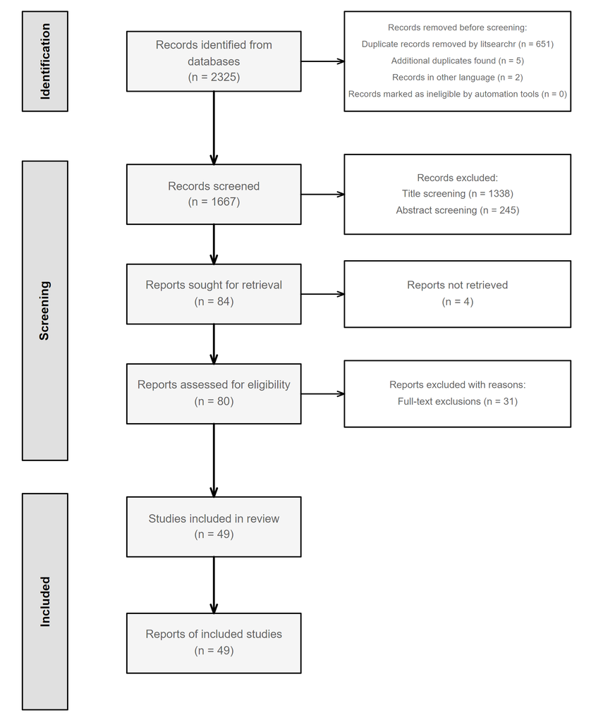

Figure 1 illustrates the literature selection process that identified studies for our analysis. The selection criteria ensured that our analysis captured only studies that could meaningfully inform SUoA selection practices. Most exclusions occurred due to insufficient spatial detail, focus on offender residence rather than crime location, or absence of discrete choice modeling - confirming that our final dataset represents the core literature addressing our research questions.

## Data Extraction

We extracted information about SUoA usage and methodological approaches from the included crime location choice studies:

**Table 3. Data Extraction Framework**

| Category | Data Extracted |
| --- | --- |
| Study Characteristics | Citation details, geographic context, temporal scope |
| SUoA Information | Unit type, unit size, rationale for SUoA selection |
| Data Limitations and Methodological Transparency | Acknowledgment of data quality issues, methodological constraints |
| Crime and Methodological Details | Crime types studied, discrete choice model type, sampling approach |

Table 3 presents our systematic data extraction framework for analyzing SUoA selection practices across 51 observations. Data extraction was performed by the primary reviewer using a systematic approach to ensure consistency across all included studies.

### Statistical Methods

We conducted descriptive synthesis supplemented by quantitative analysis using R version 4.3.0 (R Core Team, 2023). Our analytical approach employed appropriate statistical techniques to address each research question systematically.

For SUoA size distribution analysis (RQ1), we calculated descriptive statistics and created size categories. For temporal trend analysis (RQ2), we used linear regression and mixed-effects modeling for intraclass correlation coefficients (ICC). For cross-jurisdictional analysis (RQ3), we employed descriptive country summaries and t-tests comparing between countries with Cohen’s d effect sizes.

For crime-type specificity analysis (RQ4), we conducted descriptive comparisons examining median sizes, means, and standard deviations across crime categories. For rationale of SUoA choice analysis (RQ5), we performed content analysis categorizing justifications into seven types: Data Availability, Theory-Method Alignment, Prior Research, Administrative Convenience, Practical Constraints, Scale Optimization, and Not Specified. For variable complexity analysis (RQ67), we analyzed explanatory variables across theoretical domains (environmental, demographic, economic, distance, temporal). For correlation analysis (RQ7), we computed Pearson correlation matrices for log-transformed unit size, publication year, variable counts, diversity scores, and numerically coded country/crime type variables.

# Results

## Study Selection and Data Overview

**Table 4. SUoA Size Statistics**

| Statistic | Value |
| --- | --- |
| Studies analyzed | 49 |
| Observations analyzed | 51 |
| Countries represented | 9 |
| Journals involved | 27 |
| Median unit size (km²) | 1.2 km² |
| Mean unit size (km²) | 1.633 km² |
| Smallest unit | 136 m² |
| Largest unit (km²) | 8.48 km² |
| Orders of magnitude range | 4.8 orders |
| Standard deviation (km²) | 1.911 km² |
| Skewness (original scale) | 2.108 |
| Temporal span (years) | 22 years |
| Year range | 2003 - 2025 |

Table 4 presents the summary statistics revealing the scale variation characterizing crime location choice research. The median SUoA size of 1.2 km² represents the typical scale preference, while the mean of 1.633 km² is substantially larger due to right-skewness from studies using very large regional units. The range from 136 m² individual properties to 8.48 km² districts demonstrates scale variation spanning 4.8 orders of magnitude. The high standard deviation (1.911 km²) and positive skewness (2.108) confirm the right-skewed distribution with most studies clustering around smaller to medium scales but some outliers using very large units. The temporal span of 22 years across 9 countries and 27 journals demonstrates the international scope and sustained development of this research field.

## SUoA Size Distribution (RQ1)

Crime location choice studies exhibit substantial variation in SUoA scale-4.8 orders of magnitude from 136 m² individual properties (Vandeviver et al., 2015) to 8.48 km² districts (Townsley et al., 2015). This variation reflects systematic theoretical alignment rather than arbitrary choices. Studies examining property-level crimes employ the finest SUoA to avoid methodological problems inherent in larger units. As Vandeviver et al. (2015) explain: “the use of fine-grained SUoA analysis such as the house that is burglarized has the advantage that it addresses the modifiable areal unit problem and reduces the risk of aggregation bias.” Studies analyzing graffiti location choice use street segments because “the spatial resolution of a street segment naturally corresponds to human observational limitations” and these units “possess attributes suitable for direct sensory perception, making it especially relevant for measuring exposure” (Kuralarasan et al., 2024). The distribution shows a mean SUoA size of 1.633 km², which exceeds the median due to the right-skewed distribution with some very large units. Studies using the largest SUoA enable analysis of broad spatial patterns across metropolitan areas (Song et al., 2017) (Figure 2).

**Figure 2. SUoA size distribution**

[figure not shown]

**Figure 3. SUoA size categories**

[figure not shown]

Figure 3 provides a categorical view of how studies distribute across meaningful size ranges, revealing that 24% of studies use medium-scale SUoA (0.25-1.0 km²), while 8% employ micro-scale units (<0.01 km²). Larger-scale SUoA (≥1.0 km², 51%) are also commonly used across the literature.

## Temporal Trends in SUoA Selection (RQ2)

Despite significant improvements in computer power and spatial data over two decades, studies show no clear trend toward smaller SUoA. Mixed-effects analysis reveals no significant temporal trend (*β* = 0.01, *p* = 0.738), suggesting that national data infrastructures and research traditions may influence methodological choices alongside technological capabilities. While technological advances have expanded analytical possibilities, the lack of a significant temporal trend indicates that SUoA selection continues to reflect multiple factors including data availability, practical constraints, and theoretical considerations. Figure 4 shows considerable variation in SUoA sizes over time without a systematic shift toward finer spatial resolution.

**Figure 4. Temporal trends in SUoA sizes**

[figure not shown]

Figure 4 shows considerable variation in SUoA sizes over time without a systematic shift toward finer spatial resolution, demonstrating that technological advances have not driven methodological standardization.

**Figure 5. SUoA sizes by time period**

[figure not shown]

Figure 5 shows no clear pattern of temporal change in SUoA selection across three distinct time periods. The similar median values and overlapping interquartile ranges across 2000-2010, 2011-2020, and 2021-2025 suggest that technological advances have not led to a systematic shift toward finer spatial resolution over time.

## Cross-National Variation in SUoA Selection (RQ3)

Countries cluster strongly in their SUoA preferences, with substantial country-level clustering (ICC = 0.386) demonstrating that national contexts significantly influence methodological decisions.

**Figure 6. Cross-national SUoA variation**

[figure not shown]

Figure 6 demonstrates substantial country-level effects on SUoA selection, with countries showing consistent internal preferences while exhibiting dramatic between-country variation. Belgian studies cluster around very small spatial units (median 0.0008 km²) reflecting data availability, while Australian studies consistently use large spatial units (median 8.48 km²). Dutch studies use units with median 2.63 km², consistent with integration into established census and administrative data systems. Contrary to expectations, there’s no difference between Anglo-Saxon countries (UK, USA, Canada, Australia, New Zealand) and other countries (*t*-test *p* = 0.747, Cohen’s *d* = -0.327). For example, Vandeviver et al. (2015) analyze individual houses (136 m²) because “essentially, burglary is about an offender finding a suitable house to burglarize and committing his offence within a clearly confined space,” while Kuralarasan et al. (2024) use street segments (845 m²) to examine graffiti exposure because these units “naturally correspond to human observational limitations.” These examples demonstrate that researchers provide sound theoretical justifications for their SUoA choices, yet strong country-level clustering indicates that theoretical considerations must be implemented within the practical constraints imposed by national data infrastructure and research practices.

**Figure 7. Anglo-Saxon vs. other countries**

[figure not shown]

Figure 7 shows that Anglo-Saxon and other countries exhibit similar SUoA size distributions (*p* = 0.747, Cohen’s *d* = -0.327).

## Crime-Type Specificity in SUoA Selection (RQ4)

Our analysis reveals differences in SUoA selection across crime types, with researchers demonstrating theoretical alignment by matching spatial scales to the geographic processes underlying different criminal behaviors.

**Table 5. SUoA Selection by Crime Type**

| Crime Type | N Studies | Median Size (km²) | Mean Size (km²) | SD Size (km²) |
| --- | --- | --- | --- | --- |
| Burglary | 25 | 0.88 | 1.85 | 2.47 |
| Other | 13 | 0.44 | 1.34 | 1.35 |
| Robbery | 8 | 1.62 | 1.27 | 0.99 |
| Theft | 5 | 2.18 | 1.89 | 1.05 |

Table 5 reveals clear patterns in scale selection across crime types. Burglary studies (n=25) predominantly use medium-scale units (median 0.88 km²) consistent with residential neighborhood analysis. Theft studies (n=5) employ the largest units (median 2.18 km²) for broader area coverage, while robbery studies (n=8) show intermediate scales (median 1.62 km²). Other crime types (n=13) tend toward the smallest scales (median 0.44 km²), reflecting the need for fine-grained spatial analysis in specific crime contexts.

These empirical patterns reflect theoretical reasoning in SUoA selection decisions. Studies requiring fine-grained environmental analysis systematically use the smallest units. For example, drug dealing studies use street segments averaging 0.002 km² because, as Bernasco and Jacques (2015) explain, “for decision making in dealing situations, what matters are the characteristics of a place that can be seen or heard, and it seemed that street segments (‘street blocks,’ ‘face blocks’) are small enough to assure that from any point in the street segment, relevant attributes of any other point in the same segment could be seen and heard.” Property crimes employ medium-scale analysis to balance target-specific characteristics with neighborhood processes. Case-control studies of burglary use property-level analysis to “isolate property-level effects from neighborhood-level effects” by “sampling treatments and controls by neighbourhood” where “observations can be systematically compared whilst keeping all contextual characteristics on the neighbourhood-level constant” (Langton & Steenbeek, 2017). Multi-crime studies systematically use larger units averaging 1.8 km² for detecting broad spatial patterns across different crime types (Song et al., 2017; Xiao et al., 2018). This systematic pattern demonstrates that apparent methodological heterogeneity reflects theoretically-informed scale selection rather than arbitrary choices.

## SUoA Selection Rationales and Justifications (RQ5)

Studies demonstrate reasoning in their SUoA selection decisions, providing explicit justifications that reflect systematic consideration of theoretical, methodological, and practical factors rather than arbitrary choices.

**Figure 8. SUoA rationale patterns**

[figure not shown]

Figure 8 demonstrates how rationalization patterns vary across SUoA size categories using our analysis of the rationale of SUoA choice. The analysis identified seven distinct rationale categories from studies that provided multiple rationale types: Data Availability (45.1% of studies), Theory-Method (35.3%), Prior Research (27.5%), Administrative Convenience (23.5%), Practical Constraint (15.7%), Not Specified (7.8%), and Scale Optimization (7.8%). The stacked bar chart shows the percentage distribution of rationale types within each size category. This visualization clearly illustrates that smaller SUoA predominantly emphasize theoretical and methodological considerations, while studies using larger SUoA show greater reliance on data availability and practical constraints. The analysis captures the complexity of SUoA justification by properly splitting and analyzing multiple rationale categories provided by individual studies, revealing that many researchers provide detailed, multi-faceted reasoning for their scale choices rather than single-factor justifications.

## Variable Complexity and Methodological Sophistication (RQ6)

Figure 9 shows the distribution of variable complexity, with several studies employing 20 or more variables to capture the multidimensional nature of crime location choice processes.

**Figure 9. Variable complexity distribution**

[figure not shown]

Crime location choice studies incorporate varying numbers of explanatory variables across different theoretical domains. Studies used 6-39 variables (mean: 21.9, median: 21). Studies commonly include variables from multiple theoretical domains:

- **Environmental variables**: Nearly universal inclusion (90%) of land use, physical infrastructure, built environment characteristics, crime attractors/generators, and guardianship measures
- **Demographic variables**: Population characteristics (98%) including age structure, ethnic composition, household composition, residential mobility, and social cohesion measures
- **Economic variables**: Socioeconomic indicators (98%) including income levels, property values, business density, and economic deprivation indices
- **Distance variables**: Spatial accessibility measures (100%), journey-to-crime distances, network connectivity, and proximity to activity nodes
- **Temporal variables**: Time-dependent factors (100%), including temporal controls, crime history, and time-specific constraints

## Correlation Analysis and Variable Relationships (RQ7)

Correlation matrix reveals important relationships between SUoA selection and various study characteristics, demonstrating that methodological choices operate relatively independently of technological advancement and analytical sophistication.

**Figure 10. Variable correlation matrix**

[figure not shown]

Figure 10 shows correlations between continuous variables influencing SUoA selection: log unit size, publication year, total variables, and variable diversity.

Publication year shows minimal correlation with log unit size (*r* = 0.048), consistent with our earlier finding of no significant temporal trend (*β* = 0.01, *p* = 0.738), confirming that technological advances haven’t driven systematic changes in scale selection over time. Total variables shows minimal correlation with log unit size (*r* = 0.075), indicating that variable-rich methods are used across all spatial scales.

The correlation pattern demonstrates that SUoA selection reflects methodological adaptation to practical considerations and theoretical requirements rather than technological convenience or methodological limitations.

# Conclusions

This narrative review of 49 crime location choice studies provides insights into SUoA selection practices in spatial criminology. Studies demonstrate explicit reasoning for SUoA selection, with researchers incorporating extensive variable sets (6-39 variables, and mean: 21.9). Researchers show awareness of scale-dependent processes, with crime-type specificity in SUoA choices: studies of location-specific crimes such as drug dealing or graffiti writing employ small spatial units, property crimes use medium-scale spatial units, and multi-crime studies utilize larger spatial units.

Country-level clustering in SUoA preferences (ICC = 0.386) demonstrates that national data infrastructure and research contexts significantly shape methodological possibilities. Contrary to technological determinism expectations, temporal trends show no systematic shift toward finer scales (*β* = 0.01, *p* = 0.738), indicating that practical factors constrain methodological evolution. The patterns reveal systematic reasoning that combines theoretical considerations with practical constraints rather than arbitrary methodological choices.

Several limitations affect our findings. Our focus on published studies may introduce publication bias toward successful methodological applications. The narrative review approach lacks the systematic quality assessment of systematic reviews. Our analysis is limited to English-language publications and spans 22 years (2003-2025), which may be insufficient to detect longer-term methodological evolution patterns. The categorization of SUoA rationales relied on author statements that may not fully capture complex decision-making processes underlying scale selection.

Future research should examine how different SUoA affect substantive findings for identical research questions. For example, analyzing the same burglary dataset using property-level, street segment, and census block units to quantify scale effects on coefficient estimates and policy implications. Systematic comparison of SUoA selection practices across different jurisdictions could examine how differences in administrative data systems between UK Lower Super Output Areas and Dutch postal code areas influence analytical possibilities and research outcomes. Controlled studies systematically varying SUoA for identical crime phenomena, such as analyzing street robbery data across multiple scales (address points, street segments, census blocks, neighborhoods), could identify optimal scales for different theoretical mechanisms and practical applications.

The extraordinary variation in SUoA-spanning 4.8 orders of magnitude-reflects both theoretical adaptation and practical constraints. This review documents current practices and identifies opportunities for advancing methodological coherence in spatial criminology research.

# References

Arksey, H., & O’Malley, L. (2005). Scoping studies: Towards a methodological framework. *International Journal of Social Research Methodology*, *8*(1), 19–32. https://doi.org/10.1080/1364557032000119616

Baudains, P., Braithwaite, A., & Johnson, S. D. (2013). Target choice during extreme events: A discrete spatial choice model of the 2011 london riots. *Criminology*, *51*(2), 251–285. https://doi.org/10.1111/1745-9125.12004

Baumer, E., Lauritsen, J. L., Rosenfeld, R., & Wright, R. (1998). The influence of crack cocaine on robbery, burglary, and homicide rates: A cross-city, longitudinal analysis. *Journal of Research in Crime and Delinquency*, *35*(3), 316–340. https://doi.org/10.1177/0022427898035003004

Bernasco, W. (2019). Adolescent offenders’ current whereabouts predict locations of their future crimes. *PLoS One*, *14*(1), e0210733. https://doi.org/10.1371/journal.pone.0210733

Bernasco, W., Block, R., & Ruiter, S. (2013). Go where the money is: Modeling street robbers’ location choices. *Journal of Economic Geography*, *13*(1), 119–143. https://doi.org/10.1093/jeg/lbs005

Bernasco, W., & Jacques, S. (2015). Where do dealers solicit customers and sell them drugs? A micro-level multiple method study. *Journal of Contemporary Criminal Justice*, *31*(4), 376–402. https://doi.org/10.1177/1043986215608535

Brantingham, P. J., & Brantingham, P. L. (1993). Nodes, paths and edges: Considerations on the complexity of crime and the physical environment. *Journal of Environmental Psychology*, *13*(1), 3–28. https://doi.org/10.1016/S0272-4944(05)80216-9

Cohen, L. E., & Felson, M. (1979). Social change and crime rate trends: A routine activity approach. *American Sociological Review*, *44*(4), 588–608. https://doi.org/10.2307/2094589

Eck, J. E. (1995). *A general model of the geography of illicit retail marketplaces*. Criminal Justice Press.

Fotheringham, A. S., & Wong, D. W. (1991). The modifiable areal unit problem in multivariate statistical analysis. *Environment and Planning A*, *23*(7), 1025–1044. https://doi.org/10.1068/a231025

Grames, E. M., Stillman, A. N., Tingley, M. W., & Elphick, C. S. (2019). An automated approach to identifying search terms for systematic reviews using keyword co‐occurrence networks. *Methods in Ecology and Evolution*, *10*(10), 1645–1654. https://doi.org/10.1111/2041-210X.13268

Hanayama, A., Haginoya, S., Kuraishi, H., & Kobayashi, M. (2018). The usefulness of past crime data as an attractiveness index for residential burglars. *Journal of Investigative Psychology and Offender Profiling*, *15*(3), 257–270. https://doi.org/10.1002/jip.1507

Kuralarasan, K., Bernasco, W., & Vandeviver, C. (2024). Graffiti writers choose locations that optimize exposure. *Crime & Delinquency*, *70*(13), 3012–3041. https://doi.org/10.1177/00111287241287133

Langton, S. H., & Steenbeek, W. (2017). Residential burglary target selection: An analysis at the property-level using google street view. *Applied Geography*, *86*, 293–343. https://doi.org/10.1016/j.apgeog.2017.06.014

Loftin, C., & Hill, R. H. (1974). Regional subculture and homicide: An examination of the gastil-hackney thesis. *American Sociological Review*, *39*(5), 714–724. https://doi.org/10.2307/2094316

Long, D., Liu, L., Xu, M., Chen, P., & Lu, Y. (2021). Ambient population and surveillance cameras: The guardianship role in street robbers’ crime location choice. *Cities*, *115*, 103223. https://doi.org/10.1016/j.cities.2021.103223

Openshaw, S. (1984). *The modifiable areal unit problem*. Geo Books.

Pawson, R. (2002). Evidence-based policy: In search of a method. *Evaluation*, *8*(2), 157–181. https://doi.org/10.1177/1358902002008002512

R Core Team. (2023). *R: A language and environment for statistical computing*. R Foundation for Statistical Computing. https://www.R-project.org/

Smith, S. P., & Brown, D. E. (2007). Discrete choice analysis of spatial attack sites. *Information Systems and e-Business Management*, *5*(3), 255–274. https://doi.org/10.1007/s10257-007-0045-1

Song, G., Bernasco, W., Liu, L., Xiao, L., Zhou, S., & Liao, W. (2017). Crime feeds on legal activities: Daily mobility flows help to explain thieves’ target location choices. *Journal of Quantitative Criminology*, *33*(4), 831–854. https://doi.org/10.1007/s10940-019-09406-z

Steenbeek, W., & Weisburd, D. (2016). Where the action is in crime? An examination of variability of crime across different spatial units in the hague, 2001–2009. *Journal of Quantitative Criminology*, *32*(3), 449–469. https://doi.org/10.1007/s10940-015-9276-3

Townsley, M., Birks, D., Bernasco, W., Ruiter, S., Johnson, S. D., White, G., & Baum, S. (2015). Burglar target selection: A cross-national comparison. *Journal of Research in Crime and Delinquency*, *52*(1), 3–31. https://doi.org/10.1177/0022427814541447

Train, K. E. (2009). *Discrete choice methods with simulation*. Cambridge University Press.

Vandeviver, C., & Bernasco, W. (2017). The geography of crime and crime control. *Applied Geography*, *86*, 220–225. https://doi.org/10.1016/j.apgeog.2017.06.012

Vandeviver, C., Van Daele, S., & Vander Beken, T. (2015). A discrete spatial choice model of burglary target selection at the house-level. *Applied Geography*, *64*, 247–257. https://doi.org/10.1016/j.apgeog.2015.08.004

Weisburd, D., Groff, E. R., & Yang, S.-M. (2012). *The criminology of place: Street segments and our understanding of the crime problem*. Oxford University Press.

Weisburd, D., McEwen, T., et al. (2004). Mapping crime in its community setting: Event geography analysis and criminology. *Crime Mapping and Crime Prevention*, 97–140.

Xiao, L., Liu, L., Song, G., Ruiter, S., & Zhou, S. (2018). Co-offending networks and crime location choice. *Applied Geography*, *90*, 244–253. https://doi.org/10.1016/j.apgeog.2017.12.007